Skip to main content

# Cell Painting morphological profiling

Example report: 300 annotated compounds in U2OS cells (JUMP Cell Painting, TARGET2 plates)

Published

November 13, 2026

**Note**

**This is a portfolio example built on public data.** It starts from CellProfiler well-level features, the usual hand-off point after image analysis. Client projects can also start from raw images (segmentation and feature extraction with CellProfiler, or deep-learning embeddings), and the same downstream steps apply to brightfield and other high-content assays.

```python
import numpy as np, pandas as pd, matplotlib.pyplot as plt, seaborn as sns
from pycytominer import normalize, feature_select
from IPython.display import Markdown, display
plt.rcParams.update({"figure.dpi": 110, "font.size": 10, "axes.spines.top": False, "axes.spines.right": False})
D = "/mnt/storage/cellpainting/"
plates = ["BR00121438", "BR00121439", "BR00121436", "BR00121425"]
pm = pd.read_csv(D + "target2_platemap.tsv", sep="\t").rename(columns={"well_position": "Metadata_Well", "broad_sample": "Metadata_broad_sample"})
meta = pd.read_csv(D + "target2_meta.tsv", sep="\t").rename(columns={"broad_sample": "Metadata_broad_sample", "pert_iname": "Metadata_name",
                                                                       "target_list": "Metadata_targets", "control_type": "Metadata_control"})
meta = meta[["Metadata_broad_sample", "Metadata_name", "Metadata_targets", "Metadata_control"]].drop_duplicates("Metadata_broad_sample")
frames = []
for p in plates:
    d = pd.read_parquet(D + p + ".parquet")
    d = d.drop(columns=[c for c in d.columns if c.startswith("Image_")])           # image-level QC/location features are not cell phenotypes
    d = d.merge(pm[["Metadata_Well", "Metadata_broad_sample"]], on="Metadata_Well", how="left").merge(meta, on="Metadata_broad_sample", how="left")
    d["Metadata_broad_sample"] = d["Metadata_broad_sample"].fillna("DMSO")
    d["Metadata_name"] = d["Metadata_name"].fillna("DMSO")
    d["Metadata_negcon"] = d["Metadata_broad_sample"].eq("DMSO")
    frames.append(d)
raw = pd.concat(frames, ignore_index=True)
feats0 = [c for c in raw.columns if not c.startswith("Metadata_")]
metacols = [c for c in raw.columns if c.startswith("Metadata_")]
# per-plate robust normalization to the DMSO wells
norm = pd.concat([normalize(g, features=feats0, meta_features=metacols, samples="Metadata_negcon == True", method="mad_robustize", mad_robustize_epsilon=0)
                  for _, g in raw.groupby("Metadata_Plate")], ignore_index=True)
norm[feats0] = norm[feats0].replace([np.inf, -np.inf], np.nan)
sel = feature_select(norm, features=feats0, operation=["variance_threshold", "correlation_threshold", "drop_na_columns", "blocklist", "drop_outliers"],
                     corr_threshold=0.9, outlier_cutoff=500)
feats = [c for c in sel.columns if not c.startswith("Metadata_")]
n_missing = int(sel[feats].isna().sum().sum())
sel[feats] = sel[feats].fillna(0)                    # rare missing values -> 0, i.e. the DMSO median on this scale
X = sel[feats].to_numpy(float)
n_cmp = sel.loc[~sel.Metadata_negcon, "Metadata_broad_sample"].nunique()
```

## Summary

```python
rng = np.random.default_rng(0)
def corr(a, b):
    a = a - a.mean(1, keepdims=True); b = b - b.mean(1, keepdims=True)
    return (a / np.linalg.norm(a, axis=1, keepdims=True)) @ (b / np.linalg.norm(b, axis=1, keepdims=True)).T
trt = sel[~sel.Metadata_negcon].reset_index(drop=True); Xt = trt[feats].to_numpy(float)
groups = trt.groupby("Metadata_broad_sample").indices
rep = {k: np.median(corr(Xt[v], Xt[v])[np.triu_indices(len(v), 1)]) for k, v in groups.items() if len(v) >= 2}
# null: median correlation among 4 wells drawn from 4 different compounds (one per plate), same sampling structure as replicates
plate_idx = {p: np.where(trt.Metadata_Plate.values == p)[0] for p in plates}
null = []
for _ in range(10000):
    idx = [rng.choice(plate_idx[p]) for p in plates]
    c = corr(Xt[idx], Xt[idx]); null.append(np.median(c[np.triu_indices(4, 1)]))
null = np.array(null); thr = np.quantile(null, 0.95)
R = pd.DataFrame({"Metadata_broad_sample": list(rep), "rep_corr": list(rep.values())}).merge(meta, on="Metadata_broad_sample", how="left")
R["reproducible"] = R.rep_corr > thr
pct = 100 * R.reproducible.mean()
display(Markdown(f"""
- **Data:** U2OS cells treated with the JUMP **TARGET2** compound set (about 300 compounds with annotated targets plus controls), stained with the six-dye Cell Painting assay and imaged; four replicate 384-well plates from one consortium site (source 4, Jump Cell Painting Consortium, Cell Painting Gallery cpg0016).
- **Features:** {len(feats0):,} CellProfiler measurements per well (shape, intensity, texture, granularity and correlation across five channels in nuclei, cells and cytoplasm), reduced to **{len(feats):,}** informative, non-redundant features after normalizing each plate to its 64 DMSO control wells.
- **Reproducible phenotypes:** **{R.reproducible.sum()} of {len(R)} compounds ({pct:.0f}%)** gave a profile whose four replicates agreed more closely than 95% of random four-well sets (replicate correlation threshold {thr:.2f}).
- **Biology:** the target-retrieval section tests whether compounds that share an annotated target produce similar profiles, against a shuffled-label baseline.
"""))
```

- **Data:** U2OS cells treated with the JUMP **TARGET2** compound set (about 300 compounds with annotated targets plus controls), stained with the six-dye Cell Painting assay and imaged; four replicate 384-well plates from one consortium site (source 4, Jump Cell Painting Consortium, Cell Painting Gallery cpg0016).

- **Features:** 3,673 CellProfiler measurements per well (shape, intensity, texture, granularity and correlation across five channels in nuclei, cells and cytoplasm), reduced to **545** informative, non-redundant features after normalizing each plate to its 64 DMSO control wells.

- **Reproducible phenotypes:** **251 of 306 compounds (82%)** gave a profile whose four replicates agreed more closely than 95% of random four-well sets (replicate correlation threshold 0.21).

- **Biology:** the target-retrieval section tests whether compounds that share an annotated target produce similar profiles, against a shuffled-label baseline.

## Quality control

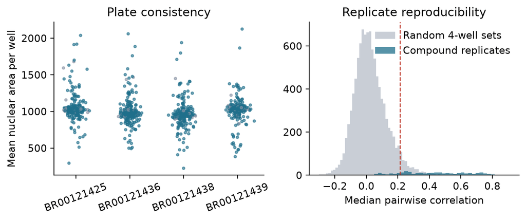

Left: mean nuclear area per well on each plate (DMSO control wells in grey), a quick check for plating or imaging drift. Right: replicate reproducibility of every compound against random well sets.

```python
fig, ax = plt.subplots(1, 2, figsize=(7.5, 3.2))
nuc = "Nuclei_AreaShape_Area" if "Nuclei_AreaShape_Area" in raw else feats0[0]
for i, (p, g) in enumerate(raw.groupby("Metadata_Plate")):
    ax[0].scatter(np.full(len(g), i) + rng.normal(0, 0.08, len(g)), g[nuc], s=6, c=np.where(g.Metadata_negcon, "#8a94a6", "#1f6f8b"), alpha=0.6)
ax[0].set_xticks(range(len(plates))); ax[0].set_xticklabels(sorted(raw.Metadata_Plate.unique()), rotation=20); ax[0].set_ylabel("Mean nuclear area per well"); ax[0].set_title("Plate consistency")
ax[1].hist(null, bins=60, color="#c9ced6", label="Random 4-well sets"); ax[1].hist(R.rep_corr, bins=40, color="#1f6f8b", alpha=0.75, label="Compound replicates")
ax[1].axvline(thr, color="#c0392b", ls="--", lw=1); ax[1].set_xlabel("Median pairwise correlation"); ax[1].set_title("Replicate reproducibility"); ax[1].legend(frameon=False)
plt.tight_layout(); plt.show()
```

Each plate was normalized separately: every feature was centred on the plate’s DMSO median and scaled by the DMSO median absolute deviation, which removes most plate-to-plate drift. The right panel is the key quality metric: compound replicates (blue) sit well to the right of random well sets (grey) when the assay is working.

## Most active compounds

```python
act = sel[~sel.Metadata_negcon].copy()
act["strength"] = np.sqrt((act[feats] ** 2).mean(1))
cons = act.groupby("Metadata_broad_sample").agg(strength=("strength", "median")).reset_index().merge(R, on="Metadata_broad_sample")
top = cons[cons.reproducible].sort_values("strength", ascending=False).head(15)
display(Markdown(top.assign(Targets=top.Metadata_targets.fillna("").str.split("|").apply(lambda t: ", ".join(t[:4]) + (f" +{len(t) - 4} more" if len(t) > 4 else "")),
                            Control=top.Metadata_control.fillna("compound"))
                 [["Metadata_name", "Targets", "Control", "strength", "rep_corr"]]
                 .rename(columns={"Metadata_name": "Compound", "strength": "Effect size (robust z)", "rep_corr": "Replicate corr."})
                 .round(2).to_markdown(index=False)))
```

| Compound | Targets | Control | Effect size (robust z) | Replicate corr. |
| --- | --- | --- | --- | --- |
| NVP-ADW742 | IGF1R | poscon_cp | 34.9 | 0.42 |
| ceritinib | ALK, FLT3, IGF1R, INSR +1 more | compound | 24.31 | 0.32 |
| ponatinib | ABL1, BCR, FGFR1, FGFR2 +11 more | compound | 22.16 | 0.54 |
| UNC1999 | EZH2 | poscon_cp | 20.17 | 0.6 |
| delanzomib | CMA1, CTSG, CYP3A4, ELANE | compound | 19.66 | 0.73 |
| SU3327 | MAPK8 | compound | 19.19 | 0.33 |
| AZD7762 | CHEK1, CHEK2 | poscon_diverse | 18.38 | 0.66 |
| ryuvidine | CDK2, CDK4 | compound | 18.34 | 0.59 |
| LDN-212854 | ABL1, ACVR1, RIPK2 | compound | 16.41 | 0.63 |
| NSC-632839 | SENP2, USP1, USP2, USP7 | poscon_cp | 16.41 | 0.76 |
| NSC-663284 | CDC25A, CDC25B, CDC25C | compound | 15.77 | 0.55 |
| romidepsin | HDAC1, HDAC2, HDAC3, HDAC4 +5 more | poscon_cp | 14.48 | 0.72 |
| puromycin | NHP2L1, RPL10L, RPL11, RPL13A +9 more | compound | 13.95 | 0.71 |
| homoharringtonine | RPL3 | compound | 12.98 | 0.73 |
| 7-hydroxystaurosporine | CHEK1, MARK3, PDPK1 | compound | 12.37 | 0.66 |

Effect size is the root-mean-square robust z-score across selected features (how far the profile is from DMSO), using the median of the four replicates. Strong, reproducible profiles are the compounds a screen would follow up.

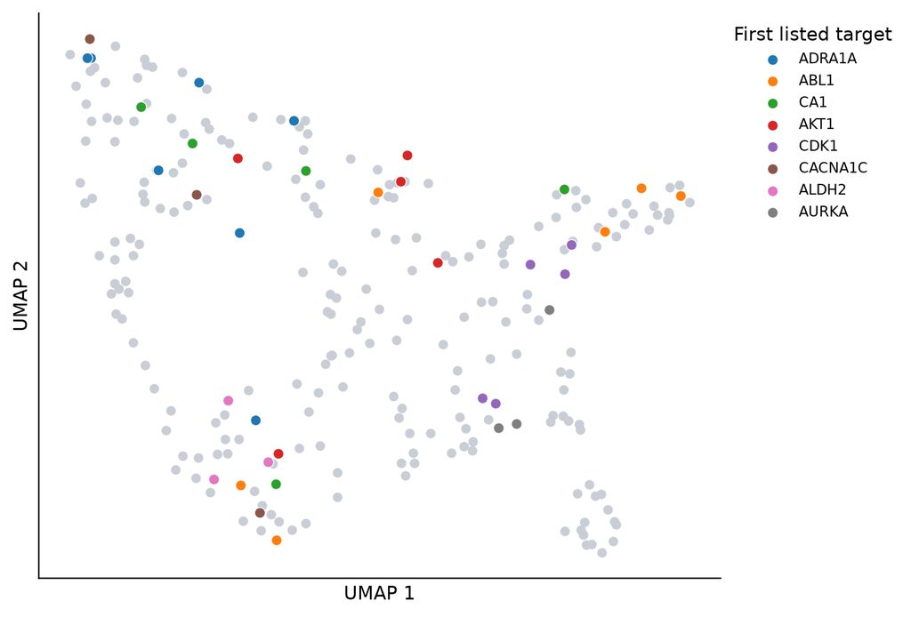

UMAP of compound consensus profiles (median of replicates) for reproducible compounds, coloured by the most common annotated targets.

```python
import umap
cp = sel[~sel.Metadata_negcon].groupby("Metadata_broad_sample")[feats].median()
keep = R.loc[R.reproducible, "Metadata_broad_sample"]
cp = cp.loc[cp.index.isin(keep)]
lab = meta.set_index("Metadata_broad_sample").reindex(cp.index)
first = lab.Metadata_targets.fillna("").str.split("|").str[0]
common = first.value_counts(); common = common[(common.index != "") & (common >= 3)].index[:8]
emb = umap.UMAP(n_neighbors=10, min_dist=0.3, metric="cosine", random_state=0).fit_transform(cp.to_numpy())
fig, ax = plt.subplots(figsize=(7, 4.8))
ax.scatter(emb[:, 0], emb[:, 1], s=18, c="#c9ced6")
pal = sns.color_palette("tab10", len(common))
for t, c in zip(common, pal):
    m = first.values == t
    ax.scatter(emb[m, 0], emb[m, 1], s=34, color=c, label=t, edgecolor="white", linewidth=0.5)
ax.set_xticks([]); ax.set_yticks([]); ax.set_xlabel("UMAP 1"); ax.set_ylabel("UMAP 2"); ax.legend(frameon=False, fontsize=8, title="First listed target", bbox_to_anchor=(1, 1))
plt.tight_layout(); plt.show()
```

## Do compounds with the same target look alike?

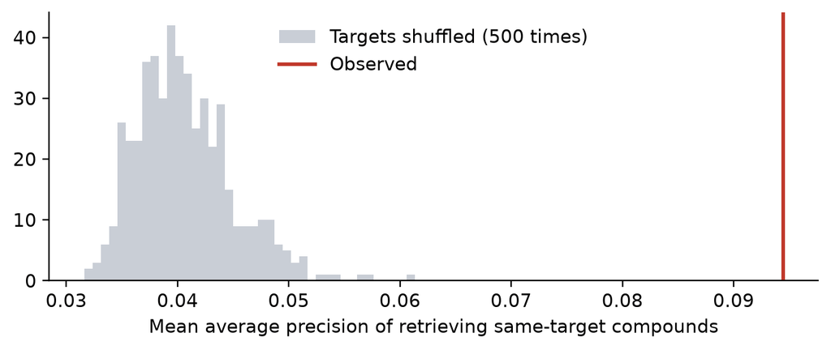

For each of the **226** reproducible compounds that shares at least one annotated target with another reproducible compound, all other compounds were ranked by profile similarity and scored by how high the same-target compounds ranked (average precision; other batches of the same molecule were not counted as matches). The observed mean is **0.094** against a shuffled-label baseline of **0.041** (permutation p = 0.002).

```python
def ap(scores, pos):
    o = np.argsort(-scores); h = pos[o]
    if h.sum() == 0: return np.nan
    prec = np.cumsum(h) / np.arange(1, len(h) + 1)
    return (prec * h).sum() / h.sum()
C = corr(cp.to_numpy(), cp.to_numpy()); np.fill_diagonal(C, -np.inf)
tl = lab.Metadata_targets.fillna("").str.split("|").apply(lambda x: set(t for t in x if t))
names = lab.Metadata_name.fillna("").values
def target_map(tsets):
    out = []
    for i in range(len(tsets)):
        if not tsets[i]: continue
        # positives share a target; another batch of the same molecule is excluded so it can't count as a "hit"
        pos = np.array([bool(tsets[i] & tsets[j]) and names[j] != names[i] if j != i else False for j in range(len(tsets))])
        if pos.sum() == 0: continue
        out.append(ap(np.delete(C[i], i), np.delete(pos, i)))
    return np.nanmean(out), len(out)
obs, n_q = target_map(list(tl.values))
perm = []
for _ in range(500):
    perm.append(target_map(list(tl.sample(frac=1, random_state=int(rng.integers(1e9))).values))[0])
perm = np.array(perm); p_val = (1 + (perm >= obs).sum()) / (1 + len(perm))
fig, ax = plt.subplots(figsize=(6.5, 2.8))
ax.hist(perm, bins=40, color="#c9ced6", label="Targets shuffled (500 times)"); ax.axvline(obs, color="#c0392b", lw=2, label="Observed")
ax.set_xlabel("Mean average precision of retrieving same-target compounds"); ax.legend(frameon=False); plt.tight_layout(); plt.show()
display(Markdown(f"For each of the **{n_q}** reproducible compounds that shares at least one annotated target with another reproducible compound, all other compounds were ranked by profile similarity and scored by how high the same-target compounds ranked (average precision; other batches of the same molecule were not counted as matches). The observed mean is **{obs:.3f}** against a shuffled-label baseline of **{perm.mean():.3f}** (permutation p = {p_val:.3f})."))
```

## Methods (ready to paste into a manuscript)

```python
import pycytominer, sklearn
print(f"""> Well-level CellProfiler profiles for four replicate JUMP TARGET2 compound plates (U2OS cells; source 4 of the JUMP Cell Painting Consortium; Cell Painting Gallery dataset cpg0016) were annotated with the TARGET2 plate map and compound metadata. Image-level features were removed, leaving {len(feats0):,} features. Each plate was normalized to its DMSO wells by robust z-scoring (median and median absolute deviation) with pycytominer, and features were filtered by near-zero variance, pairwise correlation (> 0.9), missing values, a standard blocklist and extreme outliers, retaining {len(feats):,} features; the {n_missing} remaining missing values were set to 0 (the DMSO median). Replicate reproducibility was assessed as the median pairwise Pearson correlation of a compound's four replicate wells, compared with 10,000 random four-well sets drawn one per plate; compounds above the null 95th percentile were called reproducible. Consensus profiles (median across replicates) were embedded with UMAP (cosine distance). Target retrieval was quantified as the mean average precision of ranking same-target compounds by profile correlation, excluding other batches of the same molecule, compared with 500 permutations of the target labels.""")
```

> Well-level CellProfiler profiles for four replicate JUMP TARGET2 compound plates (U2OS cells; source 4 of the JUMP Cell Painting Consortium; Cell Painting Gallery dataset cpg0016) were annotated with the TARGET2 plate map and compound metadata. Image-level features were removed, leaving 3,673 features. Each plate was normalized to its DMSO wells by robust z-scoring (median and median absolute deviation) with pycytominer, and features were filtered by near-zero variance, pairwise correlation (> 0.9), missing values, a standard blocklist and extreme outliers, retaining 545 features; the 2 remaining missing values were set to 0 (the DMSO median). Replicate reproducibility was assessed as the median pairwise Pearson correlation of a compound’s four replicate wells, compared with 10,000 random four-well sets drawn one per plate; compounds above the null 95th percentile were called reproducible. Consensus profiles (median across replicates) were embedded with UMAP (cosine distance). Target retrieval was quantified as the mean average precision of ranking same-target compounds by profile correlation, excluding other batches of the same molecule, compared with 500 permutations of the target labels.

## Deliverables in a client project

- This report, with figures as high-resolution PNG and vector PDF
- Normalized and feature-selected profiles, per well and per compound (Parquet and CSV), with hit calls and effect sizes
- If starting from images: CellProfiler pipelines (or model code), segmentation QC overlays for a sample of fields, and per-cell feature tables
- Analysis code to reproduce every number, and a 30-minute call to review hits